# Debugging `sceptre` 8: Schraivogel enhancer screen data and positive controls

## Schraivogel enhancer screen data

Next, I examine the Schraivogel enhancer screen data. First, I make a histogram of the number of nonzero cells per gRNA:

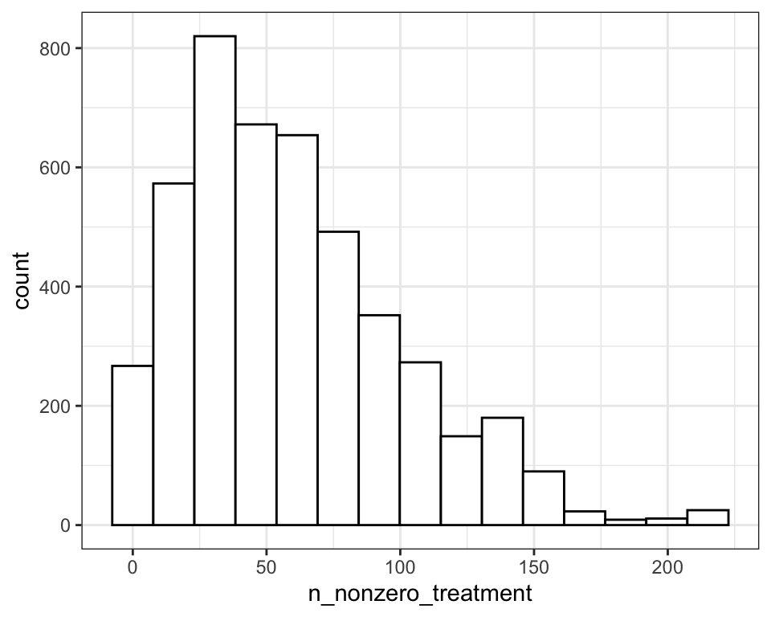

Expression levels of course are greater on the Schraivogel enhancer screen data than on the Papalexi and Frangieh data. Only a handful of negative control pairs (34) have zero treatment cells with nonzero expression.

```r
sample_size_df_nt |>
  filter(n_nonzero_treatment == 0) |>
  nrow()
```

```
## [1] 34
```

Meanwhile, about 95% of pairs pass the (somewhat arbitrary) QC threshold have having at least seven treatment cells with nonzero expression and 30 control cells with nonzero expression.

```r
n_pass_qc <- sample_size_df_nt |>
  filter(n_nonzero_treatment >= 7, n_nonzero_control >= 30) |>
  nrow()
n_total <- sample_size_df_nt |> nrow()
n_pass_qc/n_total
```

```
## [1] 0.9492375
```

Thus, issues related to sample size likely are less pressing on the Schraivogel enhancer screen data than on the Papalexi and Frangieh data.

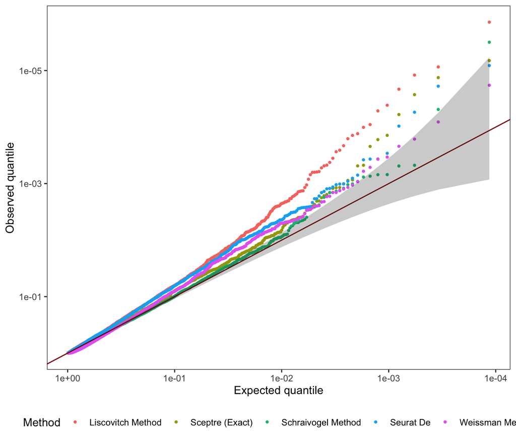

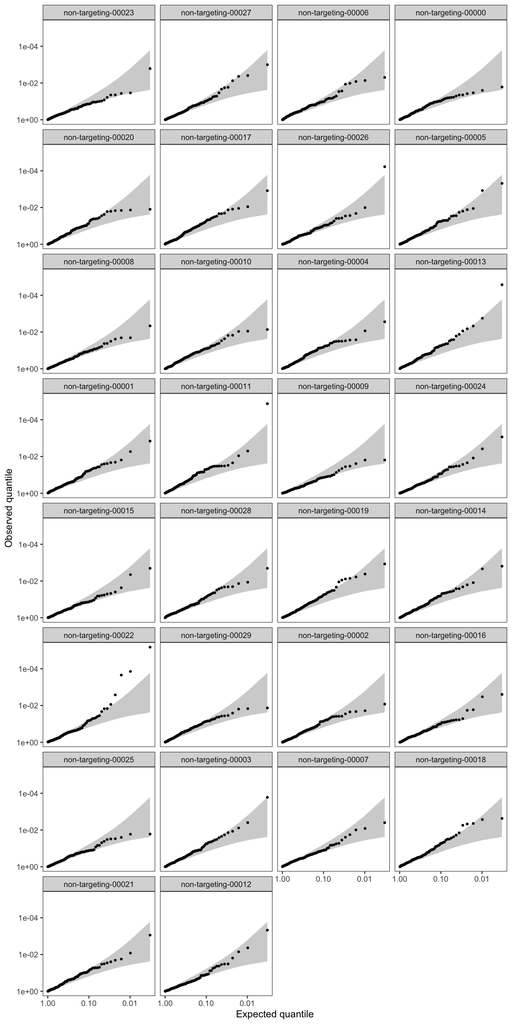

The most inflated gRNA is non-targeting-00022. Interestingly, non-targeting-00022 also poses the greatest difficulty on the Schraivogel perturb-seq dataset. I plot the results of Fisher exact test on the pertub-seq data below, faceting by gRNA.

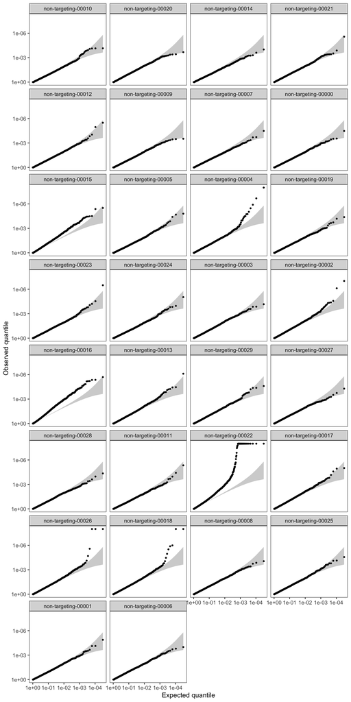

Perhaps this is evidence of off-targeting effects among some gRNAs? At any rate, removing non-targeting-00022 does not change the calibration of the methods too much (not plotted).